# Case Study: Employee Attrition

Alex Salamah

Nov 2019

# Define the Goals:

- Using attrition Data Set, identify the top three factors that contribute to turnover/attrition. Also, explore job role specific trends that may exist in the data set (e.g., “Data Scientists have the highest job satisfaction”).
- build a model to predict attrition

# List of needed Libraries

## Initial Meta Data and Data Profiling Analysis

```
## Skim summary statistics
##  n obs: 870
##  n variables: 36
##
## -- Variable type:factor ----------------------------------------------------------------------------------------------------------------------------
##        variable missing complete   n n_unique
##       Attrition       0      870 870        2
##  BusinessTravel       0      870 870        3
##      Department       0      870 870        3
##  EducationField       0      870 870        6
##          Gender       0      870 870        2
##         JobRole       0      870 870        9
##   MaritalStatus       0      870 870        3
##          Over18       0      870 870        1
##        OverTime       0      870 870        2
##                             top_counts ordered
##               No: 730, Yes: 140, NA: 0   FALSE
##     Tra: 618, Tra: 158, Non: 94, NA: 0   FALSE
##     Res: 562, Sal: 273, Hum: 35, NA: 0   FALSE
##  Lif: 358, Med: 270, Mar: 100, Tec: 75   FALSE
##              Mal: 516, Fem: 354, NA: 0   FALSE
##  Sal: 200, Res: 172, Lab: 153, Man: 87   FALSE
##    Mar: 410, Sin: 269, Div: 191, NA: 0   FALSE
##                          Y: 870, NA: 0   FALSE
##               No: 618, Yes: 252, NA: 0   FALSE
##
## -- Variable type:integer ---------------------------------------------------------------------------------------------------------------------------
##                  variable missing complete   n     mean      sd   p0
##                       Age       0      870 870    36.83    8.93   18
##                 DailyRate       0      870 870   815.23  401.12  103
##          DistanceFromHome       0      870 870     9.34    8.14    1
##                 Education       0      870 870     2.9     1.02    1
##             EmployeeCount       0      870 870     1       0       1
##            EmployeeNumber       0      870 870  1029.83  604.79    1
##   EnvironmentSatisfaction       0      870 870     2.7     1.1     1
##                HourlyRate       0      870 870    65.61   20.13   30
##                        ID       0      870 870   435.5   251.29    1
##            JobInvolvement       0      870 870     2.72    0.7     1
##                  JobLevel       0      870 870     2.04    1.09    1
##           JobSatisfaction       0      870 870     2.71    1.11    1
```

[output cut: 28 more lines]

```
##  2839.5   4945.5  8182    19999 ▇▇▃▂▁▁▁▁
##  8092    14074.5 20456.25 26997 ▆▇▇▇▇▆▇▆
##     1        2       4        9 ▇▂▂▂▁▁▁▁
##    12       14      18       25 ▇▇▃▃▁▂▂▁
##     3        3       3        4 ▇▁▁▁▁▁▁▂
##     2        3       4        4 ▅▁▅▁▁▇▁▇
##    80       80      80       80 ▁▁▁▇▁▁▁▁
##     0        1       1        3 ▇▁▇▁▁▂▁▁
##     6       10      15       40 ▅▇▂▂▁▁▁▁
##     2        3       3        6 ▁▁▇▇▁▂▂▁
##     2        3       3        4 ▁▁▃▁▁▇▁▂
##     3        5      10       40 ▇▅▁▁▁▁▁▁
##     2        3       7       18 ▇▂▁▅▁▁▁▁
##     0        1       3       15 ▇▂▁▁▁▁▁▁
##     2        3       7       17 ▇▂▁▃▁▁▁▁
```

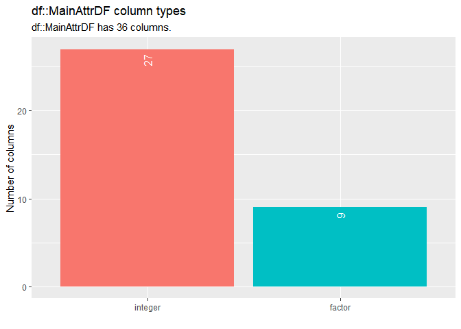

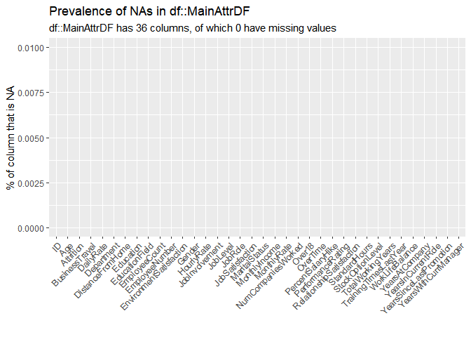

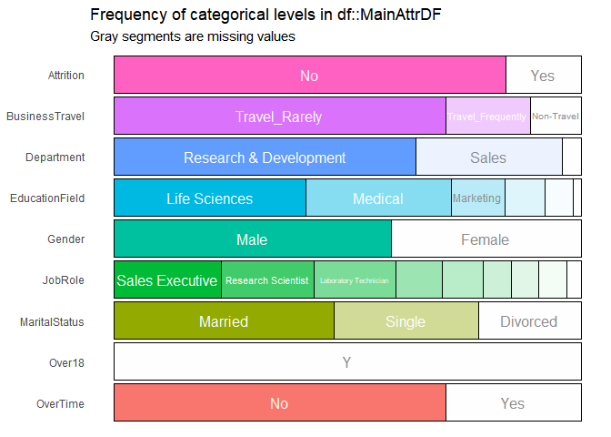

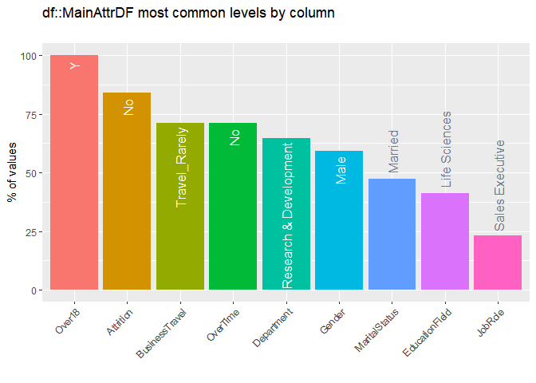

## Variable pruning

variables that have SD=0, or have one value for example over18=Yes, or provide similar information will be removed from the data set as they are not providing any analyticle value. Additional pruning was done using correlation analysis. Heat map was produced to remove attributes that are highly correlated.

## Correlated Attributes:

Identify correlated attributes using heat map and keep only one

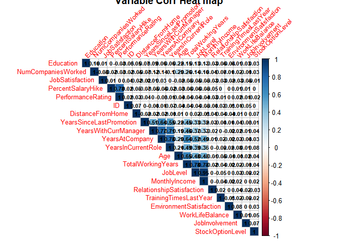

## Determine which of the numerical (discreet and continuous) attributes is important to attrition

### Age:

Age does not seem to have much impact on attrition where the average age of the employees that are is slightly lower than the average age of employees that are staying.

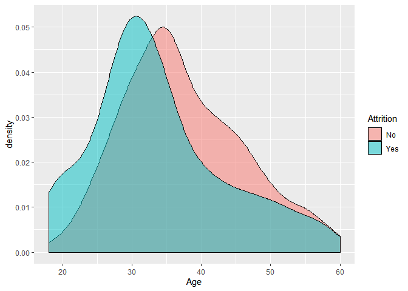

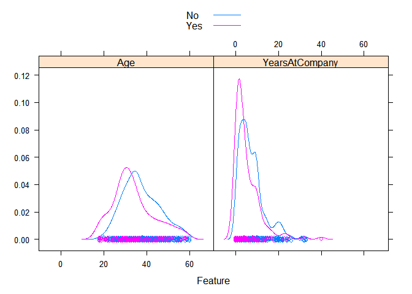

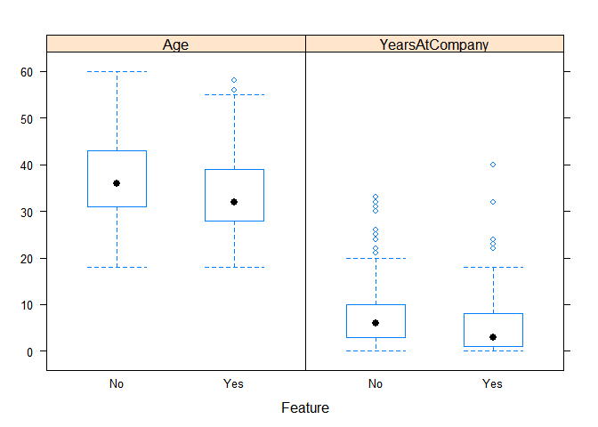

### Years At Company: The age observation closely tracks with the years at the company. This attribute also shows slight significance as it relates to attrition. The density chart shows emloyees tend to mostly leave within years 1-3

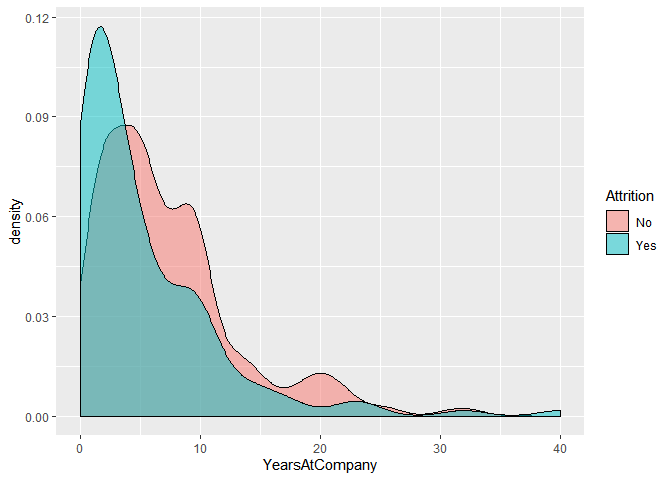

### Years with current manager: The number of years working with the same manager does not seem to have much impact on attrition.

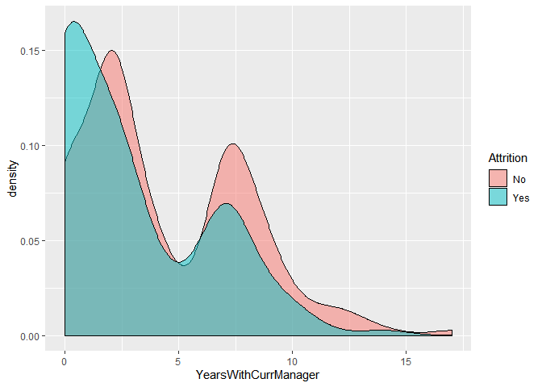

### Years in current role: The varialbe does not seem to have much impact on attrition

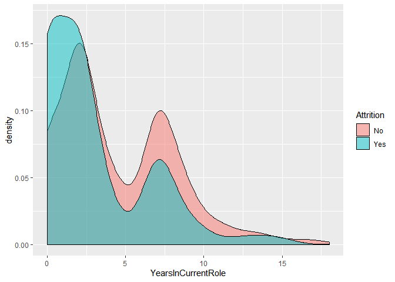

### Total Working Years:

This variable seems to have some impact on attrition as the density graph shows the density for the yes and no categories are slightly off indicating some influence.

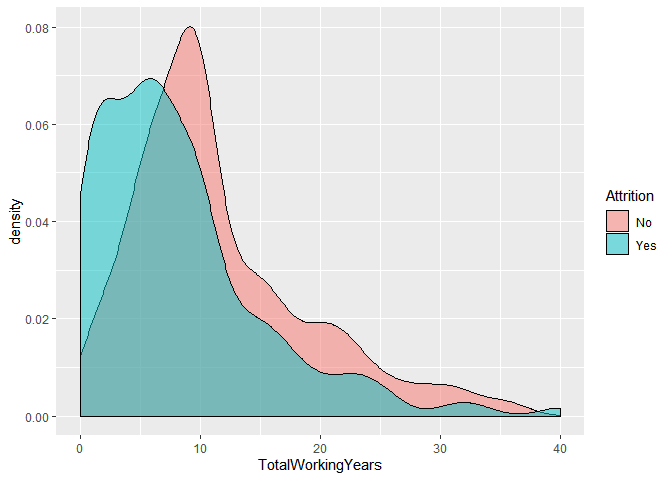

### Nonthly Income: This variable seems to have some impact on attrition as the density graph shows the density for the yes and no categories are slightly off indicating some influence.

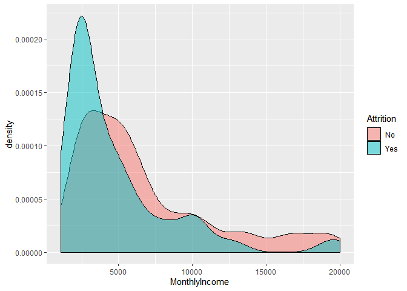

This variable doest not seem to have some impact on attrition as the density graph shows the density for the yes and no categories are almost aligned indicating minmmalinfluence.

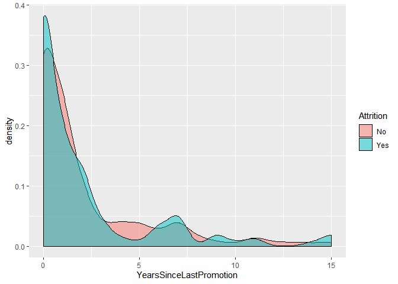

#

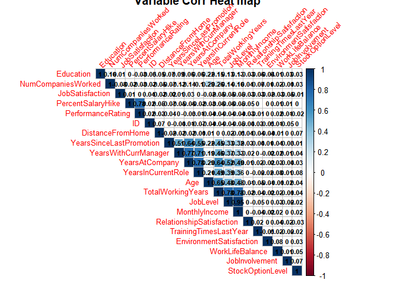

### Distance from home: This attribute appears to have an influence on attrition the density graph shows that people that have shorter commute have a higher probability of staying (not quitting)

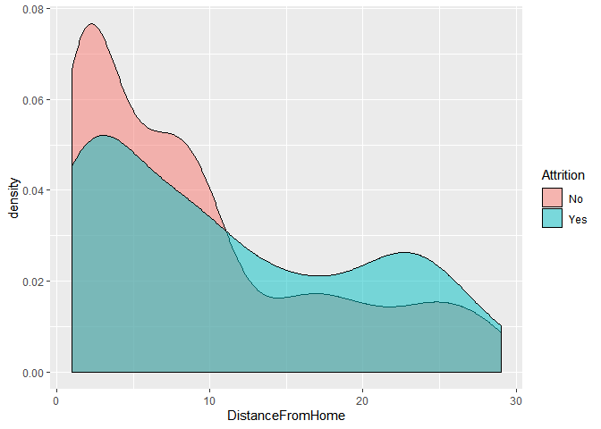

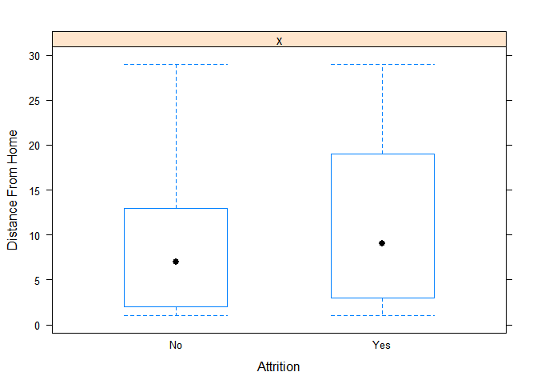

### Education level: Density chart for both attrition categories (Yes/No) is not much different base on education level. One exception is Employees with Bachelor degree (4 years) seem to have higher tendency to stay with the company.

[figure not shown]

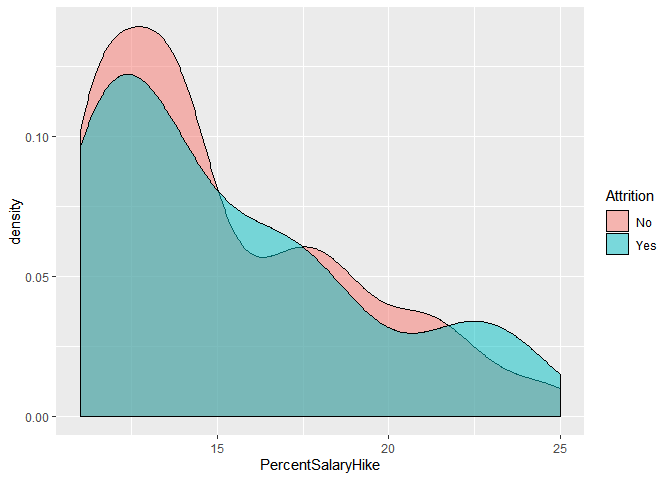

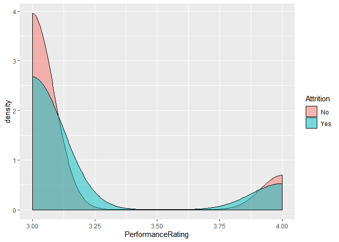

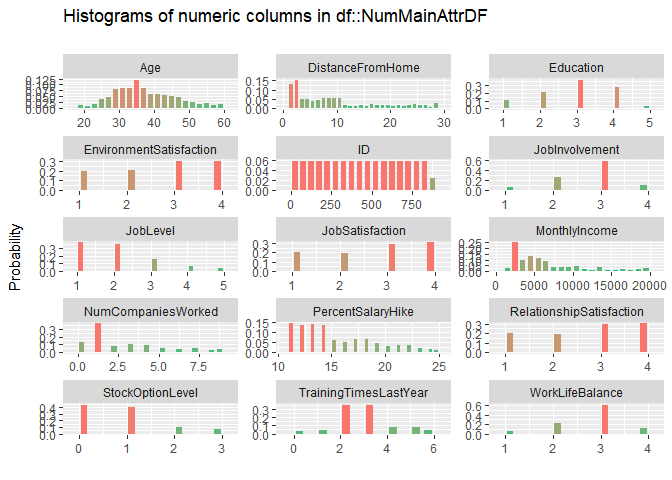

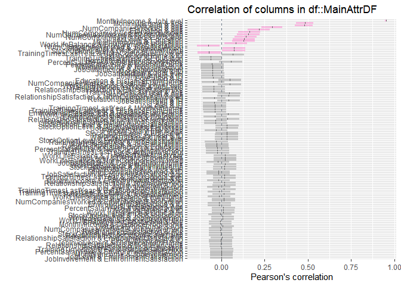

## Categorical Analysis

```
## [1] "The first 6 observations of the merged file:"
```

```
##               Department AttritionStatus AttrStatusCnt DeptCount
## 1        Human Resources              No            29        35
## 2        Human Resources             Yes             6        35
## 3 Research & Development              No           487       562
## 4 Research & Development             Yes            75       562
## 5                  Sales              No           214       273
## 6                  Sales             Yes            59       273
```

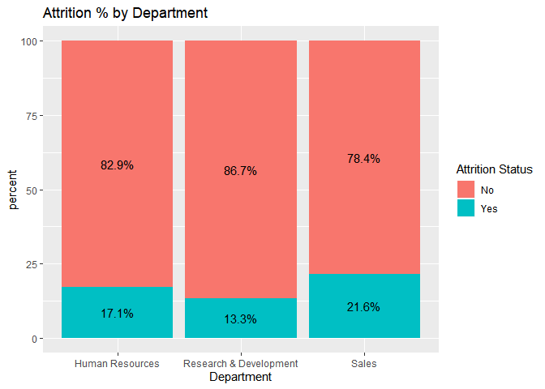

```
## [1] "The first 6 observations of the merged file:"
```

```
##    EducationField AttritionStatus AttrStatusCnt EdCount      Perc
## 1 Human Resources              No            11      15 0.7333333
## 2 Human Resources             Yes             4      15 0.2666667
## 3   Life Sciences              No           305     358 0.8519553
## 4   Life Sciences             Yes            53     358 0.1480447
## 5       Marketing              No            80     100 0.8000000
## 6       Marketing             Yes            20     100 0.2000000
```

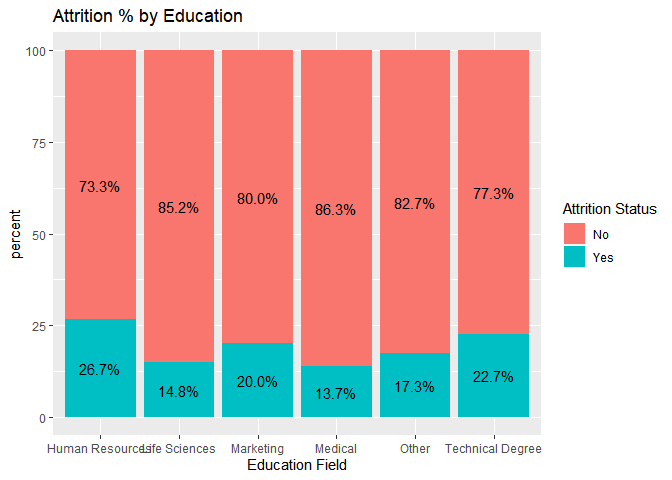

### Attrition By Gender Attrition for both is consistent and thus does not appear to be relevant to attrition

```
## 'data.frame':    870 obs. of  23 variables:
##  $ ID                      : int  1 2 3 4 5 6 7 8 9 10 ...
##  $ Age                     : int  32 40 35 32 24 27 41 37 34 34 ...
##  $ Attrition               : Factor w/ 2 levels "No","Yes": 1 1 1 1 1 1 1 1 1 1 ...
##  $ BusinessTravel          : Factor w/ 3 levels "Non-Travel","Travel_Frequently",..: 3 3 2 3 2 2 3 3 3 2 ...
##  $ Department              : Factor w/ 3 levels "Human Resources",..: 3 2 2 3 2 2 2 3 3 2 ...
##  $ DistanceFromHome        : int  13 14 18 1 2 10 5 10 10 10 ...
##  $ Education               : int  4 3 2 4 1 2 5 4 4 4 ...
##  $ EducationField          : Factor w/ 6 levels "Human Resources",..: 2 4 2 3 6 2 4 2 2 6 ...
##  $ EnvironmentSatisfaction : int  2 3 3 3 1 4 2 4 3 4 ...
##  $ Gender                  : Factor w/ 2 levels "Female","Male": 2 2 2 1 1 2 2 1 1 2 ...
##  $ JobInvolvement          : int  3 2 3 3 3 3 4 2 3 2 ...
##  $ JobLevel                : int  2 5 3 3 1 3 1 2 1 2 ...
##  $ JobRole                 : Factor w/ 9 levels "Healthcare Representative",..: 8 6 5 8 7 5 7 8 9 1 ...
##  $ JobSatisfaction         : int  4 3 4 4 4 1 3 4 3 3 ...
##  $ MaritalStatus           : Factor w/ 3 levels "Divorced","Married",..: 1 3 3 2 3 1 2 1 2 2 ...
##  $ MonthlyIncome           : int  4403 19626 9362 10422 3760 8793 2127 6694 2220 5063 ...
##  $ NumCompaniesWorked      : int  2 1 2 1 1 1 2 2 1 1 ...
##  $ OverTime                : Factor w/ 2 levels "No","Yes": 1 1 1 1 2 1 2 2 2 1 ...
##  $ PercentSalaryHike       : int  11 14 11 19 13 21 12 14 19 14 ...
##  $ RelationshipSatisfaction: int  3 1 3 3 3 3 1 3 4 2 ...
##  $ StockOptionLevel        : int  1 0 0 2 0 2 0 3 1 1 ...
##  $ TrainingTimesLastYear   : int  3 2 2 3 2 4 5 5 2 3 ...
##  $ WorkLifeBalance         : int  2 4 3 3 3 2 2 3 3 2 ...
```

```
## [1] "The first 6 observations of the merged file:"
```

```
##   Gender AttritionStatus AttrStatusCnt GdCount      Perc
## 1 Female              No           301     354 0.8502825
## 2 Female             Yes            53     354 0.1497175
## 3   Male              No           429     516 0.8313953
## 4   Male             Yes            87     516 0.1686047
```

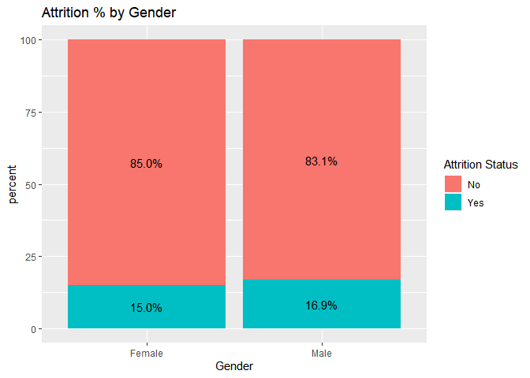

### Attrition By Job Role: This variable appears to play a significant role in attrition whereby the Sales Representative have a high attrition rate of 45.3% nearly twice as high the next job role of Human resources which has a rate of 22.2%.

[output not shown]

```
## [1] "The first 6 observations of the merged file:"
```

```
##                     JobRole AttritionStatus AttrStatusCnt GdCount
## 1 Healthcare Representative              No            68      76
## 2 Healthcare Representative             Yes             8      76
## 3           Human Resources              No            21      27
## 4           Human Resources             Yes             6      27
## 5     Laboratory Technician              No           123     153
## 6     Laboratory Technician             Yes            30     153
##        Perc
## 1 0.8947368
## 2 0.1052632
## 3 0.7777778
## 4 0.2222222
## 5 0.8039216
## 6 0.1960784
```

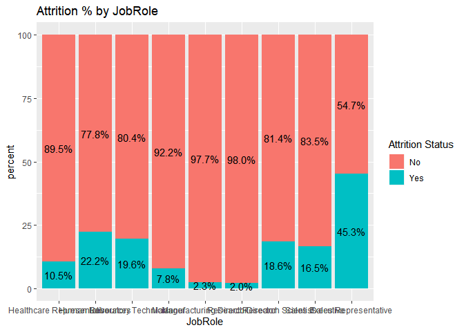

### Attrition By Marital Status: This variable appears to play a significant role in attrition whereby the singles have a high attrition rate of 26.0% nearly twice as high the married which has a rate of 14.1%.

[output not shown]

```
## [1] "The first 6 observations of the merged file:"
```

```
##   MaritalStatus AttritionStatus AttrStatusCnt GdCount       Perc
## 1      Divorced              No           179     191 0.93717277
## 2      Divorced             Yes            12     191 0.06282723
## 3       Married              No           352     410 0.85853659
## 4       Married             Yes            58     410 0.14146341
## 5        Single              No           199     269 0.73977695
## 6        Single             Yes            70     269 0.26022305
```

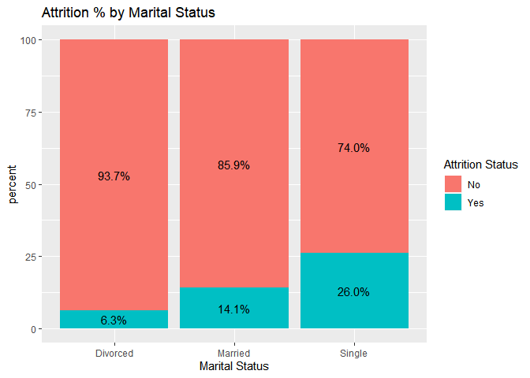

### Attrition By Over Time Status: This variable appears to play a significant role in attrition whereby over time employees have a high attrition rate of 31.7% are three times as likely to be attritioned as non-overtime employees at 9.7%.

[output not shown]

```
## [1] "The first 6 observations of the merged file:"
```

```
##   OverTime AttritionStatus AttrStatusCnt GdCount       Perc
## 1       No              No           558     618 0.90291262
## 2       No             Yes            60     618 0.09708738
## 3      Yes              No           172     252 0.68253968
## 4      Yes             Yes            80     252 0.31746032
```

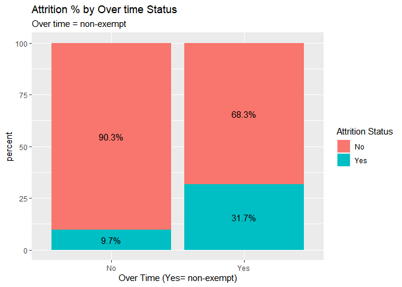

[figure not shown]

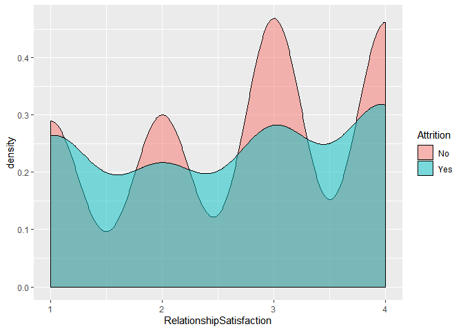

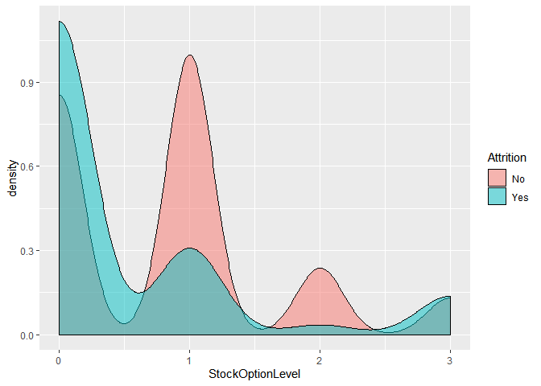

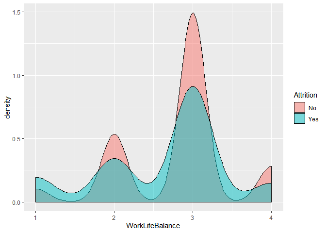

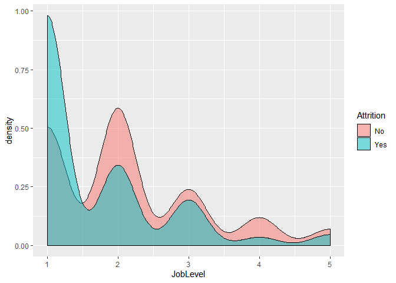

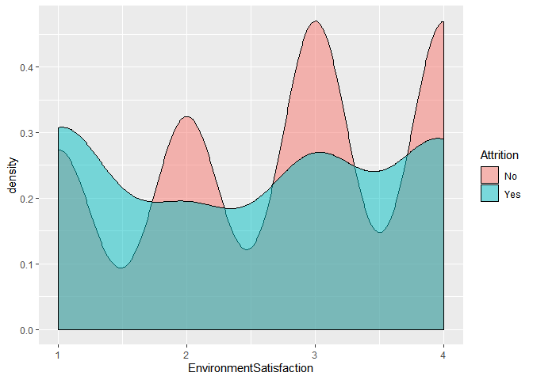

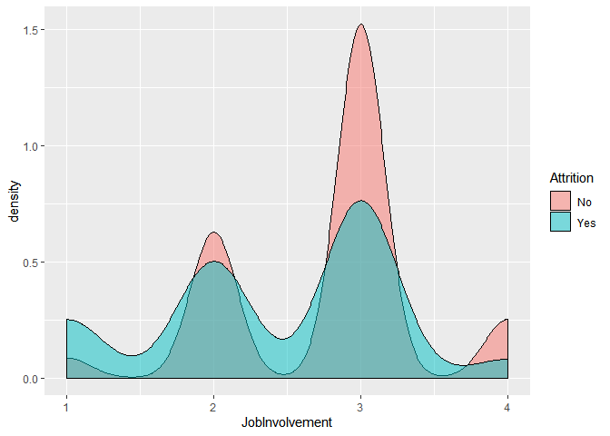

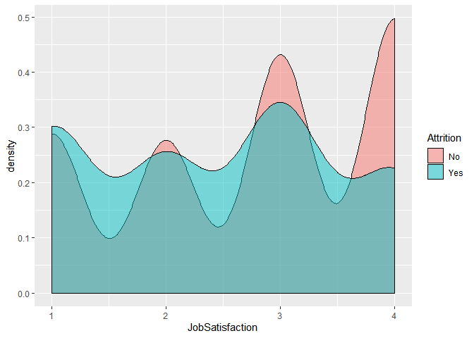

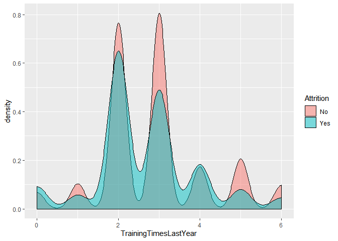

### Attrition By Stock Option Level: This variable appears to play a significant role in attrition whereby employees receiving no stock options (level 0) and those who receive the highest option (level = 3) have a high attrition rate the is almost three times that of employees the receive stock options at level 1 and 2.

```
## [1] "The first 6 observations of the merged file:"
```

```
##   StockOptionLevel AttritionStatus AttrStatusCnt GdCount       Perc
## 1                0              No           281     379 0.74142480
## 2                0             Yes            98     379 0.25857520
## 3                1              No           328     355 0.92394366
## 4                1             Yes            27     355 0.07605634
## 5                2              No            78      81 0.96296296
## 6                2             Yes             3      81 0.03703704
```

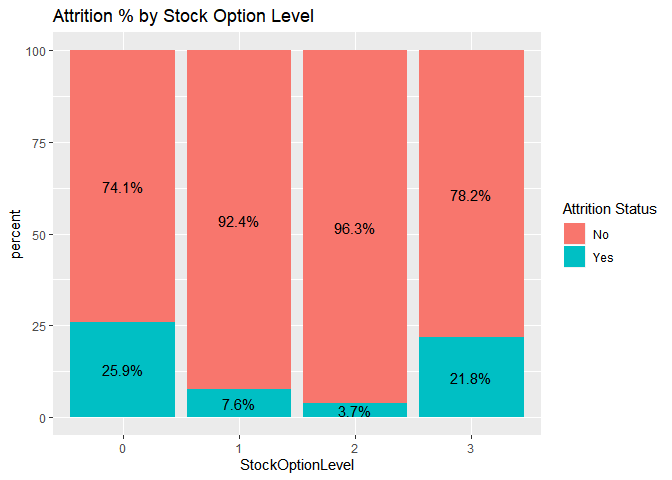

### Attrition By Work Life Balance: The majority of work-life balance categories have similar attrition rates.

```
## [1] "The first 6 observations of the merged file:"
```

```
##   WorkLifeBalance AttritionStatus AttrStatusCnt GdCount      Perc
## 1               1              No            31      48 0.6458333
## 2               1             Yes            17      48 0.3541667
## 3               2              No           162     192 0.8437500
## 4               2             Yes            30     192 0.1562500
## 5               3              No           452     532 0.8496241
## 6               3             Yes            80     532 0.1503759
```

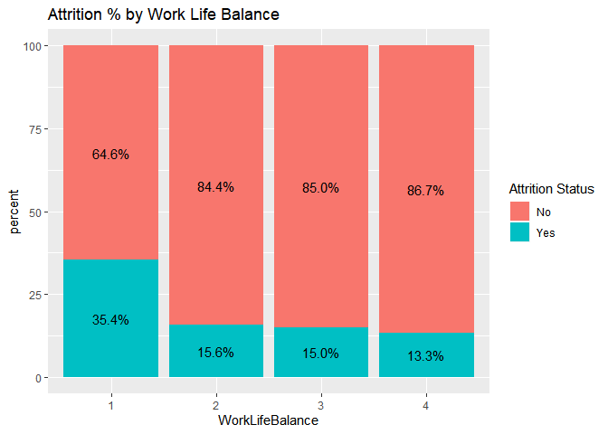

### Attrition By Job Level: This variable appears to play a significant role in attrition whereby the various job levels have drastically different attrition rates.

```
##   JobLevel AttritionStatus AttrStatusCnt GdCount       Perc
## 1        1              No           243     329 0.73860182
## 2        1             Yes            86     329 0.26139818
## 3        2              No           282     312 0.90384615
## 4        2             Yes            30     312 0.09615385
## 5        3              No           115     132 0.87121212
## 6        3             Yes            17     132 0.12878788
```

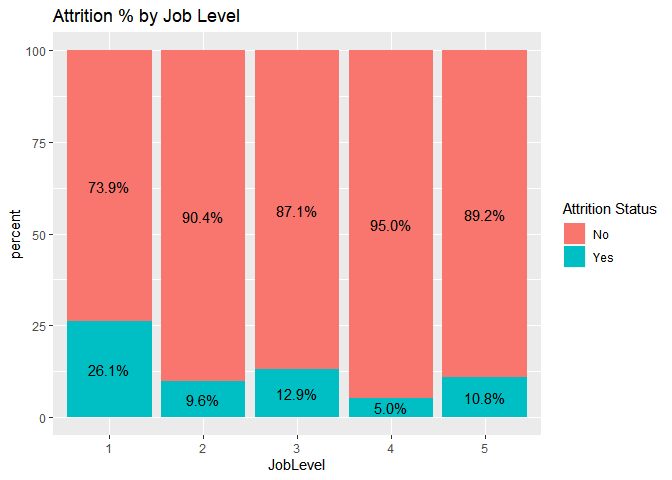

### Attrition By Environment Satisfaction: The attrition rate is mostly consistent across the various levels

```
##   EnvironmentSatisfaction AttritionStatus AttrStatusCnt GdCount      Perc
## 1                       1              No           130     172 0.7558140
## 2                       1             Yes            42     172 0.2441860
## 3                       2              No           154     178 0.8651685
## 4                       2             Yes            24     178 0.1348315
## 5                       3              No           223     258 0.8643411
## 6                       3             Yes            35     258 0.1356589
```

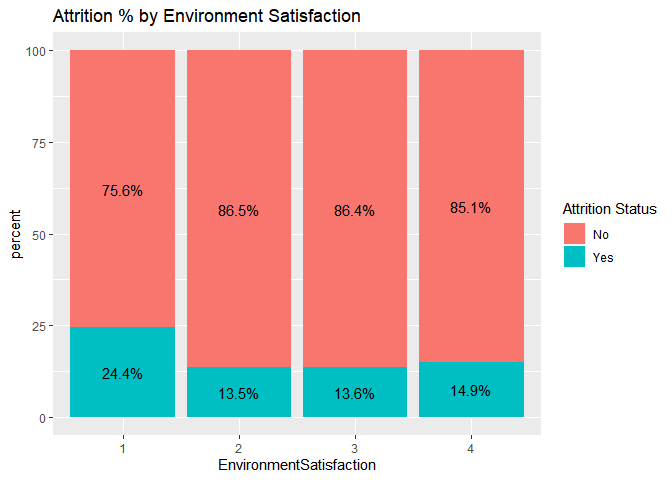

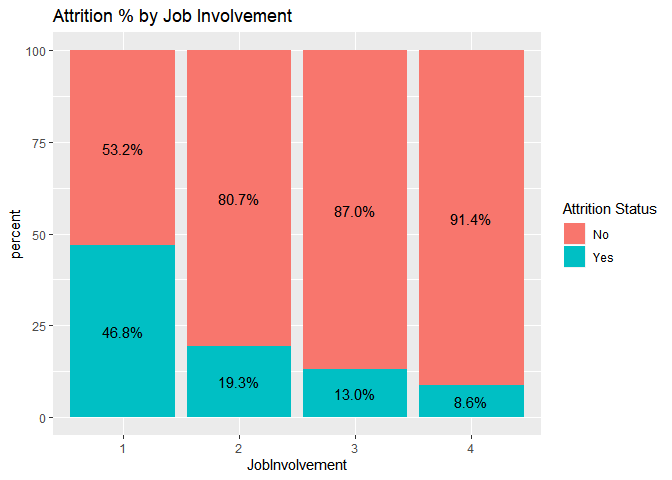

### Attrition by Job Satisfaction: This variable does not seem to have minimal influence on attrition.

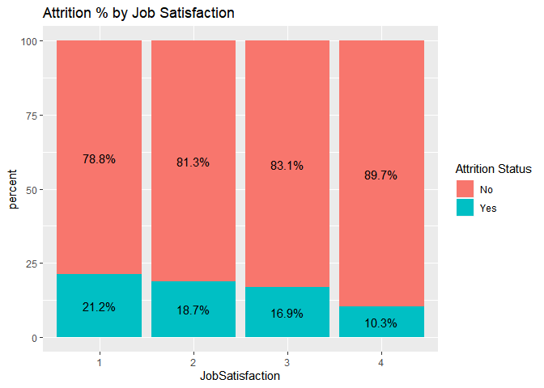

### Attrition by Training Times Last Year: This variable appears to play a significant role in attrition whereby employees receiving different levels of training have different attrition rates.

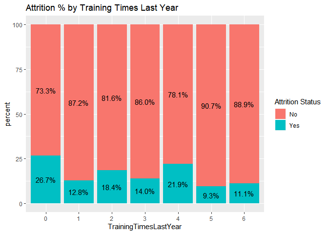

### Classify using the KNN. Tried using Under sample, Over Sample and both none of the balanced training data produced the desired effect, to I decided to use the original data set. Using the analysis of the categorical and continuous variables conducted above, the following variables were selected to fit a KNN Model: StockOptionLevel, DistanceFromHome, MonthlyIncome, JobInvolvement. Through multiple iteration of K, Seed optimization, and different train/test split ratios the following parameters were the most optimal: K= 7, Split = 85%, and Seed = 100. With these parameters, the model was fitted and trained and the below are the outcomes: prediction Accuracy = 86.1%, Specificity = 75% Sensitivity = 86.5%

```
## [1] 1
## [1] 0.7923077
## [1] 0.816
## [1] 0.2
## [1] 2
## [1] 0.8538462
## [1] 0.8730159
## [1] 0.25
## [1] 3
## [1] 0.8
## [1] 0.8253968
## [1] 0
## [1] 4
## [1] 0.8923077
## [1] 0.90625
```

[output cut: 385 more lines]

```
## Confusion Matrix and Statistics
##
##      classifications
##        No Yes
##   No  109   1
##   Yes  17   3
##
##                Accuracy : 0.8615
##                  95% CI : (0.79, 0.9158)
##     No Information Rate : 0.9692
##     P-Value [Acc > NIR] : 1.000000
##
##                   Kappa : 0.2095
##
##  Mcnemar's Test P-Value : 0.000407
##
##             Sensitivity : 0.8651
##             Specificity : 0.7500
##          Pos Pred Value : 0.9909
##          Neg Pred Value : 0.1500
##              Prevalence : 0.9692
##          Detection Rate : 0.8385
##    Detection Prevalence : 0.8462
##       Balanced Accuracy : 0.8075
##
##        'Positive' Class : No
##
```

```
## [1] 4
```

```
## [1] 4
```

```
## [1] 49
```

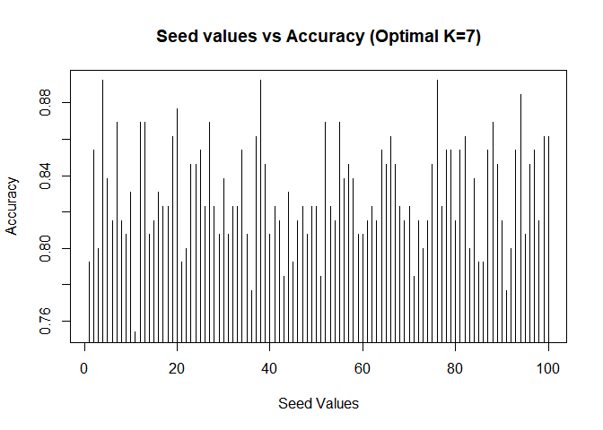

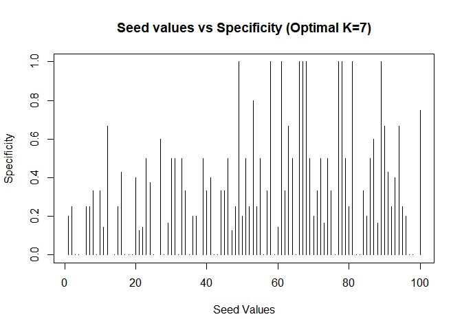

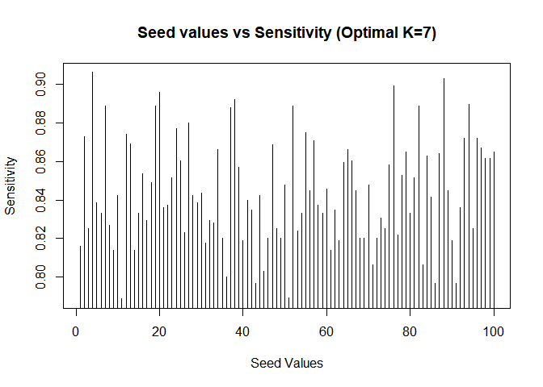

### Predict the Attrition from File

## Naive-Bayes Model:

This model produced similar results as the KNN model but the accuracy was lower, 82% versus 86% and the specificity came out to be 0. As a result, I decided to use the KNN model

```
## Confusion Matrix and Statistics
##
##
##        No Yes
##   No  107   3
##   Yes  20   0
##
##                Accuracy : 0.8231
##                  95% CI : (0.7465, 0.8844)
##     No Information Rate : 0.9769
##     P-Value [Acc > NIR] : 1.0000000
##
##                   Kappa : -0.0418
##
##  Mcnemar's Test P-Value : 0.0008492
##
##             Sensitivity : 0.8425
##             Specificity : 0.0000
##          Pos Pred Value : 0.9727
##          Neg Pred Value : 0.0000
##              Prevalence : 0.9769
##          Detection Rate : 0.8231
##    Detection Prevalence : 0.8462
##       Balanced Accuracy : 0.4213
##
##        'Positive' Class : No
##
```

## Linear Regression

### Validate assumptions: The GGPLOTS and point plots confirm the assumptions. There is no evidence against normal distributions

There does not seem to be much evidence against a linear relationship between the means and there does not seem to be much evidence of non-constant standard deviation of the normal distributions.

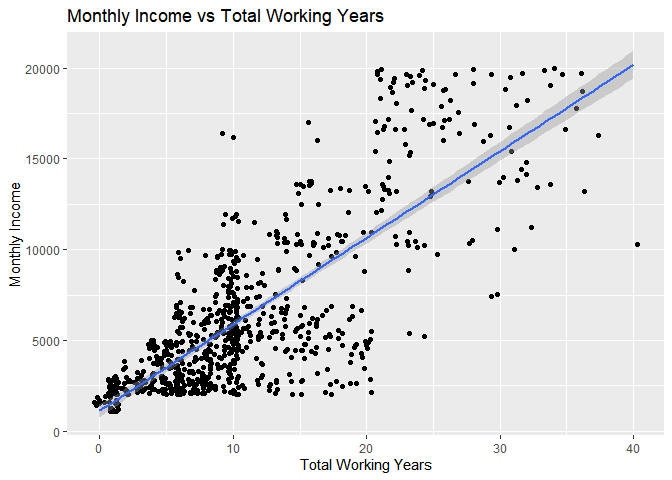

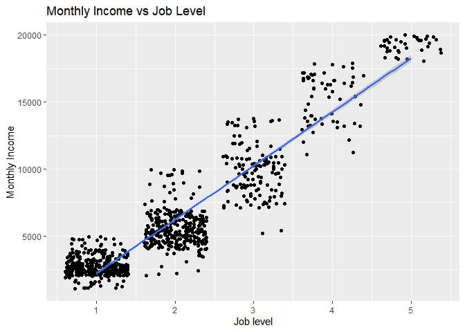

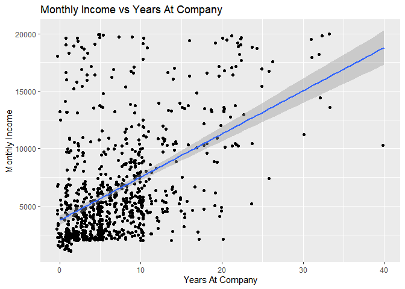

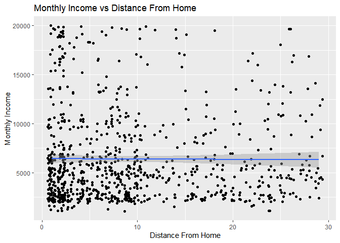

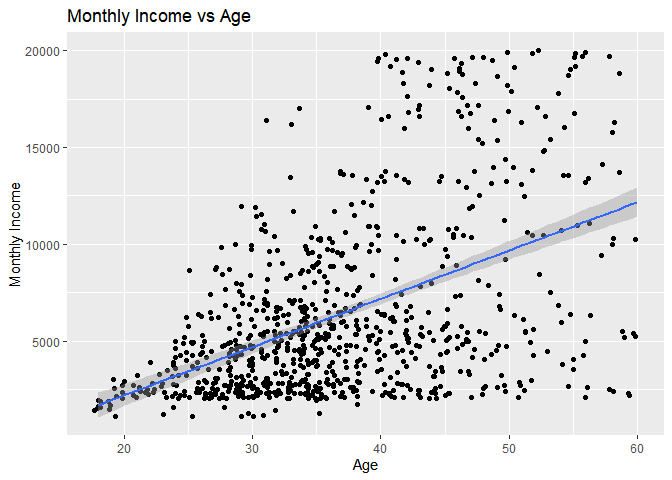

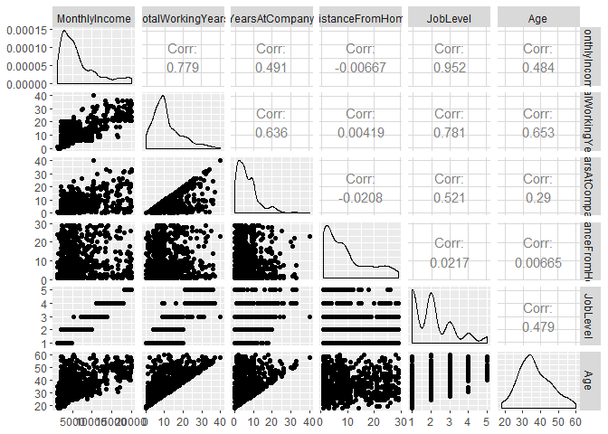

```
## [1] 1379.319
```

```
##
## Call:
## lm(formula = MonthlyIncome ~ YearsAtCompany + TotalWorkingYears +
##     JobLevel, data = NumMainAttrDF)
##
## Residuals:
##     Min      1Q  Median      3Q     Max
## -5625.1  -888.5    42.3   725.5  3968.3
##
## Coefficients:
##                   Estimate Std. Error t value Pr(>|t|)
## (Intercept)       -1764.37     100.04 -17.637  < 2e-16 ***
## YearsAtCompany      -32.04      10.11  -3.170  0.00158 **
## TotalWorkingYears    70.76      11.07   6.394 2.64e-10 ***
## JobLevel           3724.98      68.94  54.035  < 2e-16 ***
## ---
## Signif. codes:  0 '***' 0.001 '**' 0.01 '*' 0.05 '.' 0.1 ' ' 1
##
## Residual standard error: 1383 on 866 degrees of freedom
## Multiple R-squared:  0.9099, Adjusted R-squared:  0.9096
## F-statistic:  2915 on 3 and 866 DF,  p-value: < 2.2e-16
```

```
##                         2.5 %      97.5 %
## (Intercept)       -1960.72215 -1568.02112
## YearsAtCompany      -51.87443   -12.20068
## TotalWorkingYears    49.04284    92.48534
## JobLevel           3589.67851  3860.28464
```